# ENV-320: Satellite Data in Agricultural Economics

R tutorials — Day 1: Vector data · Day 2: Raster data

Authors

Affiliations

David Wuepper

[Land Economics Group, University of Bonn](https://www.ilr1.uni-bonn.de/en/research/research-groups/land-economics)

Marc Russwurm

[Machine Learning in Earth Observation Laboratory](https://meo-lab.com/)

Wyclife Agumba Oluoch

[Land Economics Group, University of Bonn](https://www.ilr1.uni-bonn.de/en/research/research-groups/land-economics)

Published

October 15, 2026

Study area for the whole course: **Kericho County, Kenya** (tea highlands). Chunks marked *not run* are shown for you to run yourself in RStudio; they are interactive, install software, or only matter on your own computer.

**TipWho are we?**

- *Name*
- *Home Country/Town*
- *Experience with R/GEE/Python*
- *Project/Research idea*

# 0. Setup

- Install `R` (≥ 4.4) and `RStudio`.
- *File › New Project › New Directory* › `env320` (keeps paths simple).

```r
pkgs <- c("terra", "sf", "geodata", "mapview", "mapedit", "exactextractr",
          "tidyverse")
install.packages(setdiff(pkgs, rownames(installed.packages())))
```

```r
dir.create("data",   showWarnings = FALSE)
dir.create("output", showWarnings = FALSE)
```

# Day 1 — Vector data (Thu 05.11.2026)

| Time | Block |
| --- | --- |
| 16:15–16:30 | 1.1 RStudio tour + R in 15 minutes |
| 16:30–16:55 | 1.2 Points |
| 16:55–17:05 | Break |
| 17:05–17:20 | 1.3 Lines and polygons; real boundaries (GADM) |
| 17:20–17:40 | 1.4 Vector operations |
| 17:40–17:45 | 1.5 Exercise |

## 1.1 R in 15 minutes

Panes: Script / Console / Environment / Files–Plots–Help. `Ctrl+Enter` runs a line.

```r
2 + 3
```

```
[1] 5
```

```r
yield <- 2.4
yield * 1000
```

```
[1] 2400
```

```r
yields <- c(2.4, 3.1, 1.8, 2.9)
mean(yields)
```

```
[1] 2.55
```

```r
length(yields)
```

```
[1] 4
```

```r
yields[2]
```

```
[1] 3.1
```

```r
yields > 2.5
```

```
[1] FALSE  TRUE FALSE  TRUE
```

```r
crops <- c("tea", "maize", "tea", "beans")
class(crops)
```

```
[1] "character"
```

```r
farms_df <- data.frame(crop = crops, yield_t_ha = yields)
farms_df
```

```
   crop yield_t_ha
1   tea        2.4
2 maize        3.1
3   tea        1.8
4 beans        2.9
```

```r
str(farms_df)
```

```
'data.frame':   4 obs. of  2 variables:
 $ crop      : chr  "tea" "maize" "tea" "beans"
 $ yield_t_ha: num  2.4 3.1 1.8 2.9
```

```r
farms_df$yield_t_ha
```

```
[1] 2.4 3.1 1.8 2.9
```

```r
farms_df[farms_df$crop == "tea", ]
```

```
  crop yield_t_ha
1  tea        2.4
3  tea        1.8
```

```r
nrow(farms_df)
```

```
[1] 4
```

```r
?mean
help(mean)
```

## 1.2 Points

### From coordinates

```r
library(terra)

coords <- cbind(lon = c(35.2863, 7.0982, 36.8219),
                lat = c(-0.3677, 50.7374, -1.2921))
towns <- vect(coords, crs = "EPSG:4326")
towns$name <- c("Kericho", "Bonn", "Nairobi")
towns
```

```
class       : SpatVector
geometry    : points
dimensions  : 3, 1  (geometries, attributes)
extent      : 7.0982, 36.8219, -1.2921, 50.7374  (xmin, xmax, ymin, ymax)
coord. ref. : lon/lat WGS 84 (EPSG:4326)
names       :    name
type        :   <chr>
values      : Kericho
                 Bonn
              Nairobi
```

```r
geom(towns)
```

```
     geom part       x       y hole
[1,]    1    1 35.2863 -0.3677    0
[2,]    2    1  7.0982 50.7374    0
[3,]    3    1 36.8219 -1.2921    0
```

```r
crs(towns, describe = TRUE)
```

```
    name authority code  area             extent
1 WGS 84      EPSG 4326 World -180, 180, -90, 90
```

### From a data.frame / csv

```r
set.seed(248)
n <- 60
farms <- data.frame(
  farm_id    = 1:n,
  lon        = runif(n, 35.05, 35.60),
  lat        = runif(n, -0.65, -0.10),
  crop       = sample(c("tea", "maize", "dairy"), n, replace = TRUE,
                      prob = c(0.5, 0.35, 0.15)),
  hh_size    = rpois(n, 5),
  income_kes = round(rlnorm(n, log(150000), 0.5))
)
write.csv(farms, "data/kericho_farms.csv", row.names = FALSE)

farms_csv <- read.csv("data/kericho_farms.csv")
head(farms_csv)
```

```
  farm_id      lon        lat  crop hh_size income_kes
1       1 35.34752 -0.2743741 maize       2      82634
2       2 35.06729 -0.1242727   tea       5     161021
3       3 35.19305 -0.1306605   tea       4     115161
4       4 35.45732 -0.3572803 maize       4     148907
5       5 35.12948 -0.3719336   tea       6     155788
6       6 35.49265 -0.2455014 maize       6     101546
```

```r
farms_v <- vect(farms_csv, geom = c("lon", "lat"), crs = "EPSG:4326",
                keepgeom = TRUE)
farms_v
```

```
class       : SpatVector
geometry    : points
dimensions  : 60, 6  (geometries, attributes)
extent      : 35.05532, 35.55318, -0.633524, -0.1004198  (xmin, xmax, ymin, ymax)
coord. ref. : lon/lat WGS 84 (EPSG:4326)
names       : farm_id     lon       lat  crop hh_size income_kes
type        :   <int>   <num>     <num> <chr>   <int>      <int>
values      :       1 35.3475 -0.274374 maize       2      82634
                    2 35.0673 -0.124273   tea       5     161021
                    3 35.1931  -0.13066   tea       4     115161
              ...
```

### By drawing (mapedit)

Opens a viewer: draw points, click *Done*. *(not run)*

```r
library(mapedit)
library(mapview)
drawn <- drawFeatures()
drawn_v <- vect(drawn)
drawn_v
```

### Plot

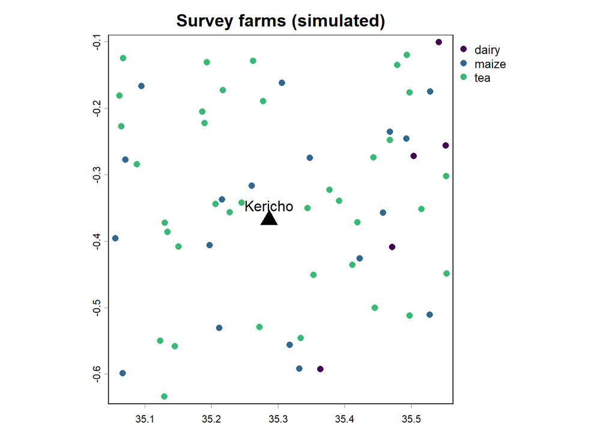

```r
plot(farms_v, "crop", pch = 16, main = "Survey farms (simulated)")
plot(towns[towns$name == "Kericho"], add = TRUE, pch = 17, cex = 2)
text(towns[towns$name == "Kericho"], labels = "name", pos = 3)
```

### Interactive map *(not run)*

```r
library(sf)
library(mapview)
mapview(st_as_sf(farms_v), zcol = "crop")
# terra alternative: plet(farms_v, "crop")
```

### Save to disk

```r
writeVector(farms_v, "output/farms_all.gpkg", overwrite = TRUE)
```

```r
writeVector(farms_v, "output/farms_all.shp", overwrite = TRUE)   # legacy format
list.files("output")
```

## 1.3 Lines and polygons

```r
route <- vect(rbind(c(35.2863, -0.3677), c(36.0800, -0.3031), c(36.8219, -1.2921)),
              type = "lines", crs = "EPSG:4326")
route$name <- "Kericho–Nakuru–Nairobi"
perim(route) / 1000
```

```
[1] 225.6757
```

```r
estate <- vect(rbind(c(35.27, -0.40), c(35.33, -0.40), c(35.33, -0.35),
                     c(35.27, -0.35), c(35.27, -0.40)),
               type = "polygons", crs = "EPSG:4326")
estate$name <- "hypothetical tea estate"
expanse(estate, unit = "ha")
```

```
[1] 3692.645
```

### Real boundaries: GADM

Level 1 = county, 2 = sub-county, 3 = ward.

```r
library(geodata)
ken1 <- gadm("KEN", level = 1, path = tempdir())
ken3 <- gadm("KEN", level = 3, path = tempdir())
```

```r
library(terra)
ken1 <- vect("data/gadm/gadm41_KEN_1_pk.rds")
ken3 <- vect("data/gadm/gadm41_KEN_3_pk.rds")

kericho <- ken1[ken1$NAME_1 == "Kericho", ]
wards   <- ken3[ken3$NAME_1 == "Kericho", ]
nrow(wards)
```

```
[1] 30
```

```r
head(as.data.frame(wards))
```

```
         GID_3 GID_0 COUNTRY    GID_1  NAME_1 NL_NAME_1      GID_2  NAME_2
1 KEN.12.1.1_1   KEN   Kenya KEN.12_1 Kericho      <NA> KEN.12.1_1 Ainamoi
2 KEN.12.1.2_1   KEN   Kenya KEN.12_1 Kericho      <NA> KEN.12.1_1 Ainamoi
3 KEN.12.1.3_1   KEN   Kenya KEN.12_1 Kericho      <NA> KEN.12.1_1 Ainamoi
4 KEN.12.1.4_1   KEN   Kenya KEN.12_1 Kericho      <NA> KEN.12.1_1 Ainamoi
5 KEN.12.1.5_1   KEN   Kenya KEN.12_1 Kericho      <NA> KEN.12.1_1 Ainamoi
6 KEN.12.1.6_1   KEN   Kenya KEN.12_1 Kericho      <NA> KEN.12.1_1 Ainamoi
  NL_NAME_2      NAME_3 VARNAME_3 NL_NAME_3 TYPE_3 ENGTYPE_3 CC_3 HASC_3
1      <NA>     Ainamoi      <NA>      <NA>   Ward      Ward  945   <NA>
2      <NA> Kapkugerwet      <NA>      <NA>   Ward      Ward  946   <NA>
3      <NA>     Kapsaos      <NA>      <NA>   Ward      Ward  949   <NA>
4      <NA>     Kapsoit      <NA>      <NA>   Ward      Ward  944   <NA>
5      <NA>   Kipchebor      <NA>      <NA>   Ward      Ward  947   <NA>
6      <NA> Kipchimchim      <NA>      <NA>   Ward      Ward  948   <NA>
```

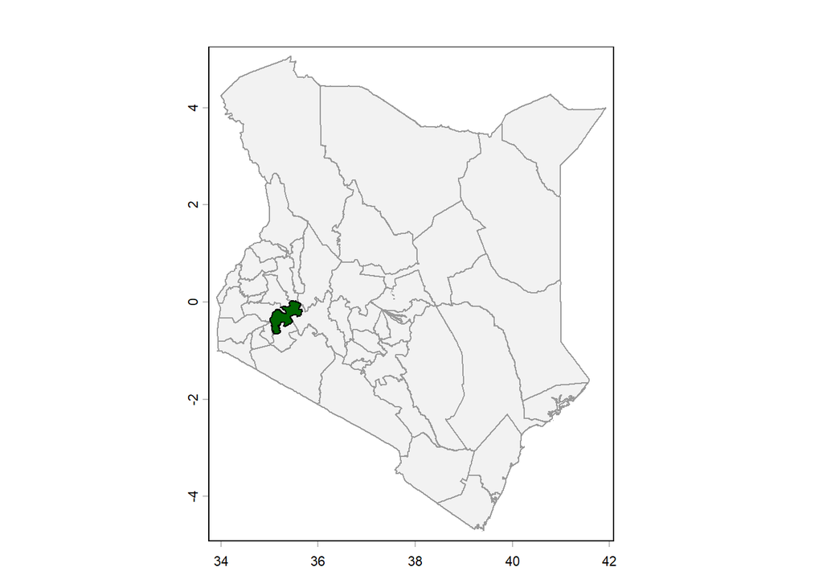

```r
plot(ken1, col = "grey95", border = "grey60")
plot(kericho, col = "darkgreen", add = TRUE)
```

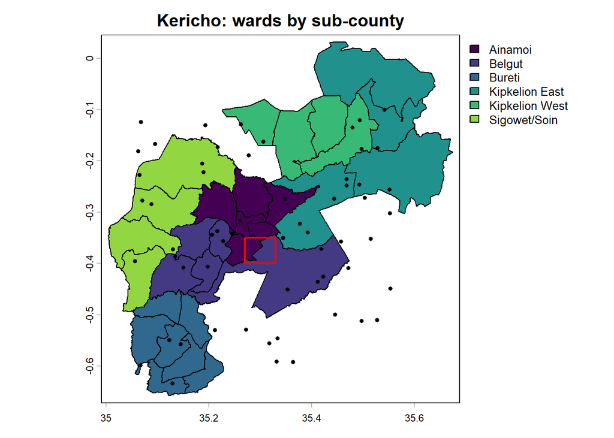

```r
plot(wards, "NAME_2", main = "Kericho: wards by sub-county")
plot(estate, add = TRUE, border = "red", lwd = 2)
plot(farms_v, add = TRUE, pch = 16, cex = 0.6)
```

## 1.4 Vector operations

### CRS and reprojection (WGS 84 / UTM 36S)

```r
kericho_utm <- project(kericho, "EPSG:32736")
crs(kericho_utm, describe = TRUE)
```

```
                   name authority  code
1 WGS 84 / UTM zone 36S      EPSG 32736
                                                                                                                                                                                                           area
1 Between 30°E and 36°E, southern hemisphere between 80°S and equator, onshore and offshore. Burundi. Eswatini (Swaziland). Kenya. Malawi. Mozambique. Rwanda. South Africa. Tanzania. Uganda. Zambia. Zimbabwe
          extent
1 30, 36, -80, 0
```

```r
expanse(kericho, unit = "km")
```

```
[1] 2576.28
```

```r
expanse(kericho_utm, unit = "km")
```

```
[1] 2576.28
```

```r
wards$area_km2 <- expanse(wards, unit = "km")
head(as.data.frame(wards[order(-wards$area_km2), c("NAME_3", "area_km2")]))
```

```
          NAME_3 area_km2
1          Chaik 250.4355
2 Kedowa/Kimugul 239.5499
3 Tendeno/Sorget 238.6287
4           Soin 184.3733
5       Chepseon 181.6941
6         Soliat 108.6723
```

### Centroids and buffers

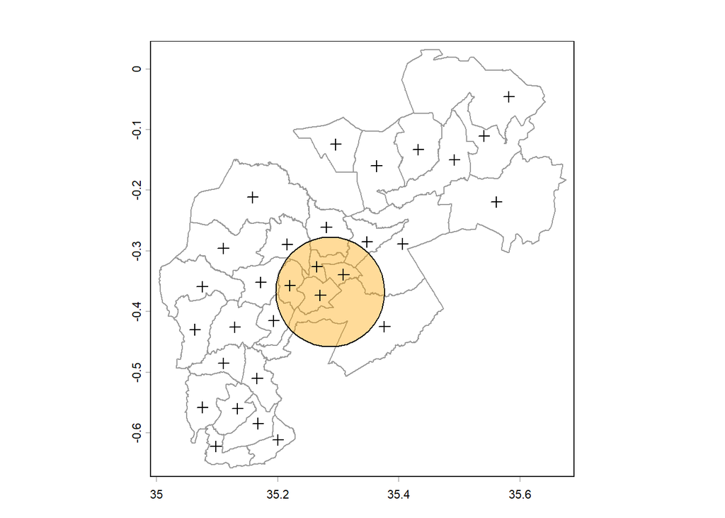

```r
ward_cent <- centroids(wards, inside = TRUE)
kericho_town <- towns[towns$name == "Kericho"]
town_buf <- buffer(kericho_town, width = 10000)     # metres

plot(wards, border = "grey60")
plot(town_buf, add = TRUE, col = adjustcolor("orange", 0.4))
plot(ward_cent, add = TRUE, pch = 3)
```

### Spatial query, spatial join, distance

```r
inside <- is.related(farms_v, kericho, "intersects")
table(inside)
```

```
inside
FALSE  TRUE
   21    39
```

```r
farms_k <- farms_v[inside, ]

farms_k <- intersect(farms_k, wards[, c("NAME_2", "NAME_3")])
names(farms_k)[names(farms_k) %in% c("NAME_2", "NAME_3")] <- c("subcounty", "ward")
head(as.data.frame(farms_k))
```

```
  farm_id      lon        lat  crop hh_size income_kes      subcounty
1       1 35.34752 -0.2743741 maize       2      82634        Ainamoi
2       5 35.12948 -0.3719336   tea       6     155788   Sigowet/Soin
3       6 35.49265 -0.2455014 maize       6     101546 Kipkelion East
4       7 35.41913 -0.3717153   tea       1     221882         Belgut
5       8 35.35305 -0.4501647   tea       5      70645         Belgut
6       9 35.55155 -0.2557584 dairy       5     107107 Kipkelion East
            ward
1        Kapsaos
2    Kaplelartet
3 Kedowa/Kimugul
4          Chaik
5          Chaik
6 Kedowa/Kimugul
```

```r
farms_k$dist_town_km <- distance(farms_k, kericho_town)[, 1] / 1000
summary(farms_k$dist_town_km)
```

```
   Min. 1st Qu.  Median    Mean 3rd Qu.    Max.
  5.394  12.299  21.245  21.112  26.978  41.118
```

```r
farms_near <- farms_k[is.related(farms_k, town_buf, "intersects"), ]
nrow(farms_near)
```

```
[1] 6
```

### Aggregate to ward level

```r
library(sf)
library(tidyverse)
ward_summary <- as.data.frame(farms_k) |>
  group_by(ward) |>
  summarise(n_farms     = n(),
            share_tea   = mean(crop == "tea"),
            mean_income = mean(income_kes),
            .groups = "drop")
ward_summary
```

```
# A tibble: 18 × 4
   ward                 n_farms share_tea mean_income
   <chr>                  <int>     <dbl>       <dbl>
 1 Chaik                      4     0.75      136254.
 2 Cheboin                    2     1         180267
 3 Cheplanget                 1     1         116349
 4 Chepseon                   6     0.833     193785.
 5 Cheptororiet/Seretut       1     0         204474
 6 Kabianga                   2     1         160644.
 7 Kaplelartet                1     1         155788
 8 Kapsaos                    1     0          82634
 9 Kapsuser                   3     0.667     149639.
10 Kedowa/Kimugul             2     0         104326.
11 Kipchimchim                2     0.5       334386
12 Kipkelion                  3     1         199043.
13 Kunyak                     2     0.5       112721
14 Londiani                   2     0         122489
15 Sigowet                    1     0          60844
16 Soin                       3     1         208965.
17 Soliat                     2     0.5       146544.
18 Tebesonik                  1     0         176868
```

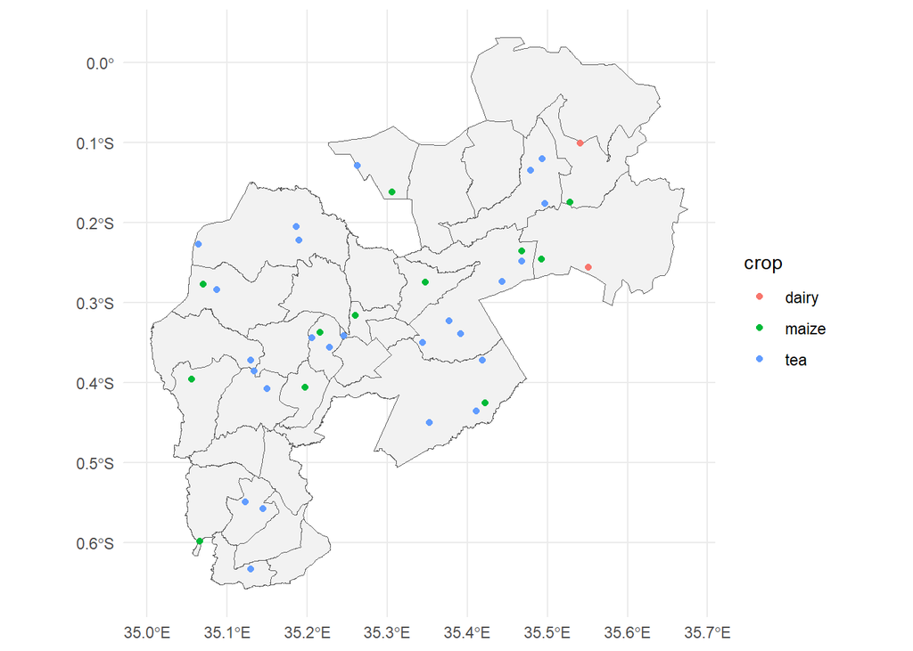

```r
ggplot() +
  geom_sf(data = st_as_sf(wards), fill = "grey95") +
  geom_sf(data = st_as_sf(farms_k), aes(colour = crop)) +
  theme_minimal()
```

```r
writeVector(farms_k, "output/kericho_farms.gpkg", overwrite = TRUE)
writeVector(wards,   "output/kericho_wards.gpkg", overwrite = TRUE)
```

## 1.5 Exercise

1. Draw your own “tea estate” with mapedit and compute its area in ha.
2. How many simulated farms lie within 5 km of it? Mean income of those farms?
3. Which ward has the highest share of tea farms?

# Day 2 — Raster data (Thu 12.11.2026)

| Time | Block |
| --- | --- |
| 16:15–16:20 | 2.0 Recap + reload |
| 16:20–16:35 | 2.1 A raster from scratch |
| 16:35–16:55 | 2.2 Elevation + climate, crop/mask, multi-layer |
| 16:55–17:05 | Break |
| 17:05–17:20 | 2.3 Raster algebra, reclassification, tea suitability |
| 17:20–17:40 | 2.4 Rasters → variables (farms, wards) |
| 17:40–17:45 | 2.5 Exercise + bridge to GEE |

**Note**

`worldclim_country()` downloads 100+ MB per variable. Run the downloads in 2.2 at home before class.

## 2.0 Recap + reload

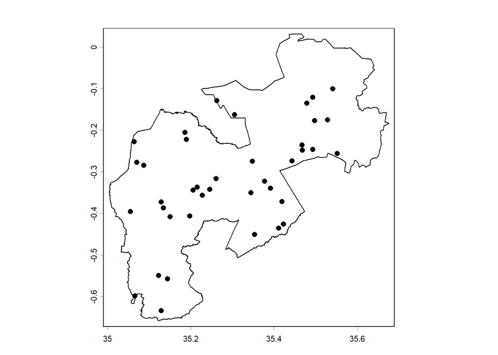

```r
library(terra)
library(sf)
library(geodata)
library(tidyverse)

farms   <- vect("output/kericho_farms.gpkg")
wards   <- vect("output/kericho_wards.gpkg")
kericho <- aggregate(wards)            # dissolve wards -> county outline
plot(kericho); plot(farms, add = TRUE, pch = 16)
```

## 2.1 A raster from scratch

```r
r <- rast(nrows = 5, ncols = 5, xmin = 35.0, xmax = 35.5,
          ymin = -0.6, ymax = -0.1, crs = "EPSG:4326")
r
```

```
class       : SpatRaster
size        : 5, 5, 1  (nrow, ncol, nlyr)
resolution  : 0.1, 0.1  (x, y)
extent      : 35, 35.5, -0.6, -0.1  (xmin, xmax, ymin, ymax)
coord. ref. : lon/lat WGS 84 (EPSG:4326)
```

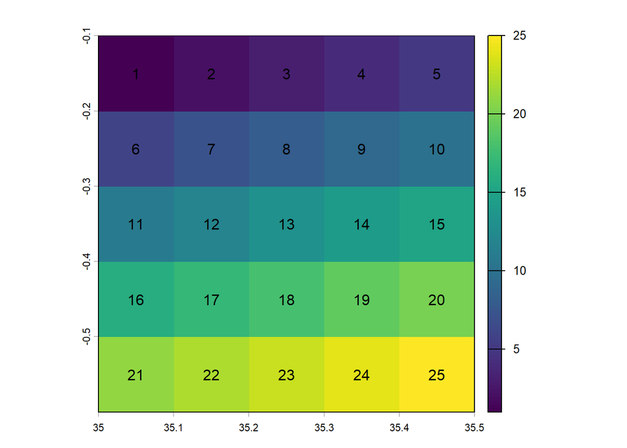

```r
values(r) <- 1:ncell(r)
plot(r); text(r)
```

```r
res(r)
```

```
[1] 0.1 0.1
```

```r
ext(r)
```

```
SpatExtent : 35, 35.5, -0.59999999999999998, -0.10000000000000001 (xmin, xmax, ymin, ymax)
```

```r
ncell(r)
```

```
[1] 25
```

```r
r[3, 3]
```

```
  lyr.1
1    13
```

```r
cellFromXY(r, cbind(35.28, -0.37))
```

```
[1] 13
```

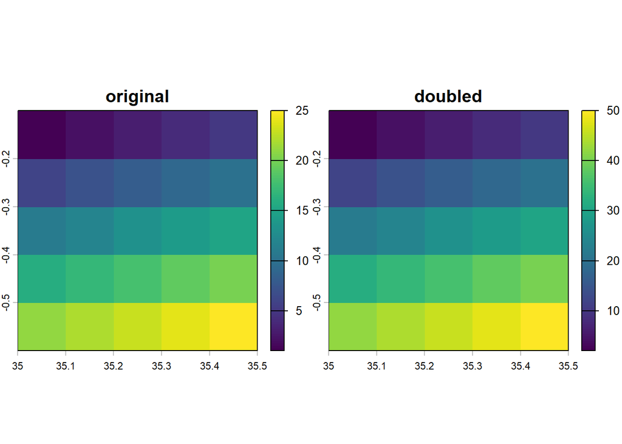

```r
r2 <- r * 2
r_stack <- c(r, r2)
names(r_stack) <- c("original", "doubled")
plot(r_stack)
```

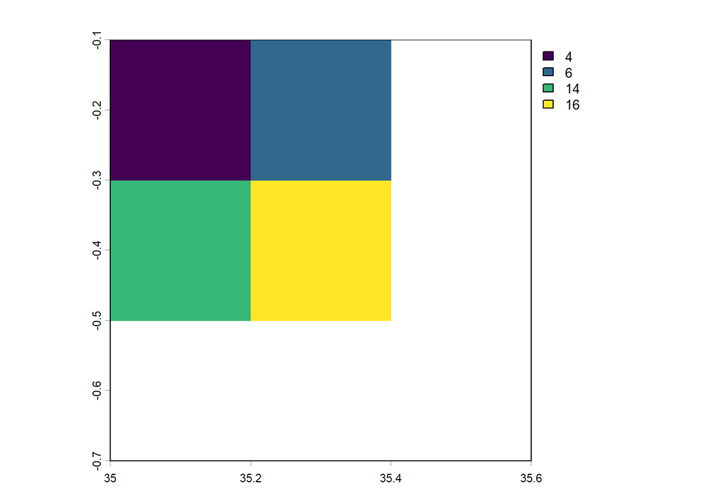

```r
plot(aggregate(r, fact = 2, fun = "mean"))
```

## 2.2 Real rasters: elevation and climate

### Elevation (SRTM-based, 30 arc-sec ≈ 1 km)

```r
elev <- elevation_30s("KEN", path = "data")
```

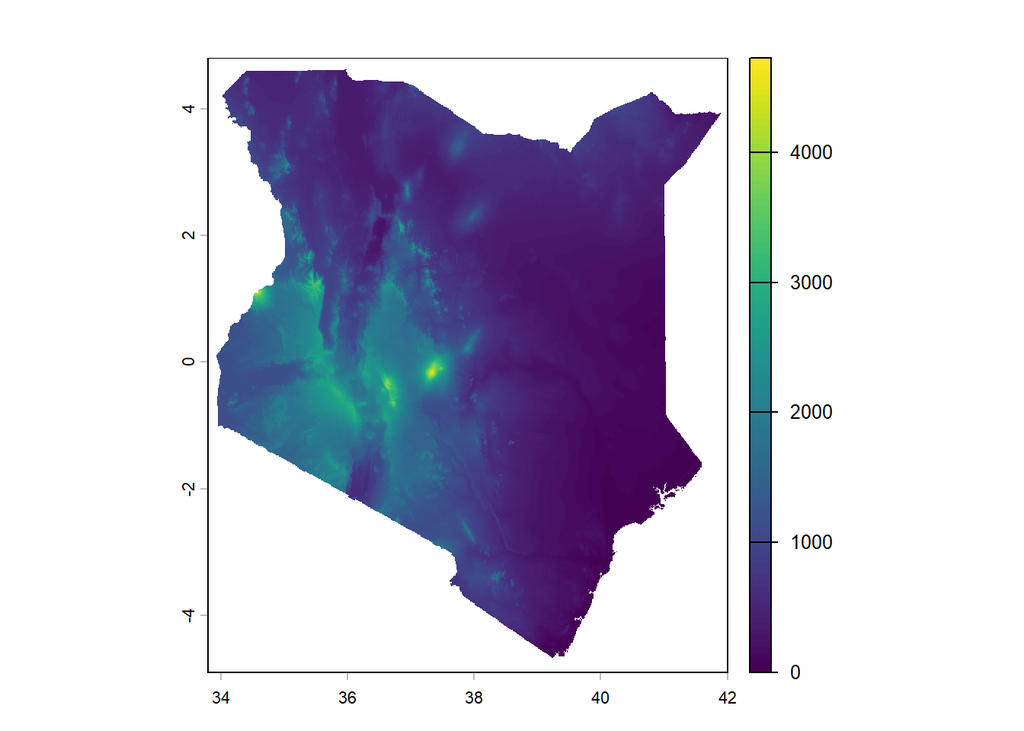

```r
elev <- rast("data/elevation/KEN_elv_msk.tif")
plot(elev)
```

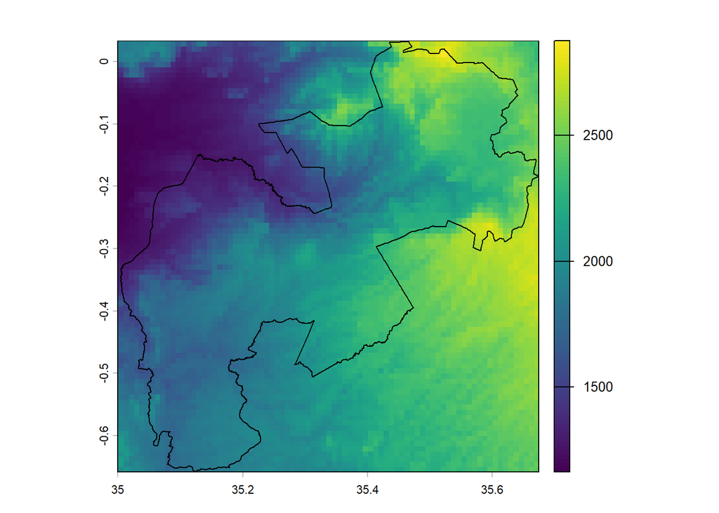

```r
elev_k <- crop(elev, kericho)
plot(elev_k); plot(kericho, add = TRUE)
```

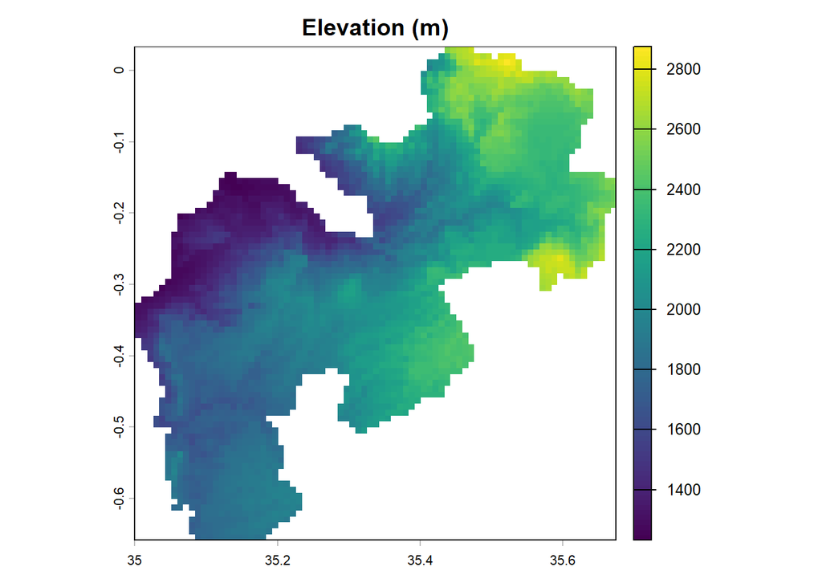

```r
elev_k <- mask(elev_k, kericho)
plot(elev_k, main = "Elevation (m)")
```

```r
global(elev_k, c("min", "max", "mean"), na.rm = TRUE)
```

```
             min  max     mean
KEN_elv_msk 1233 2875 1973.818
```

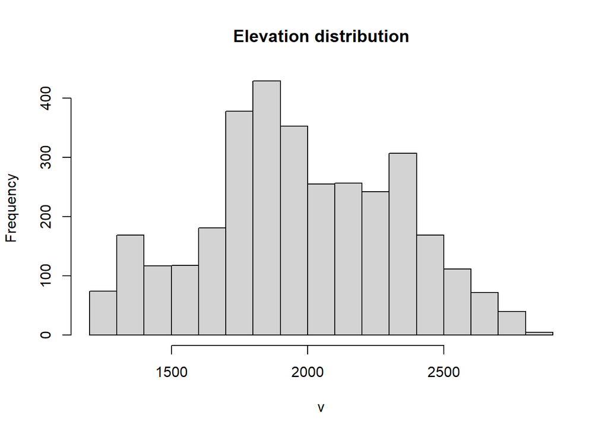

```r
hist(elev_k, main = "Elevation distribution")
```

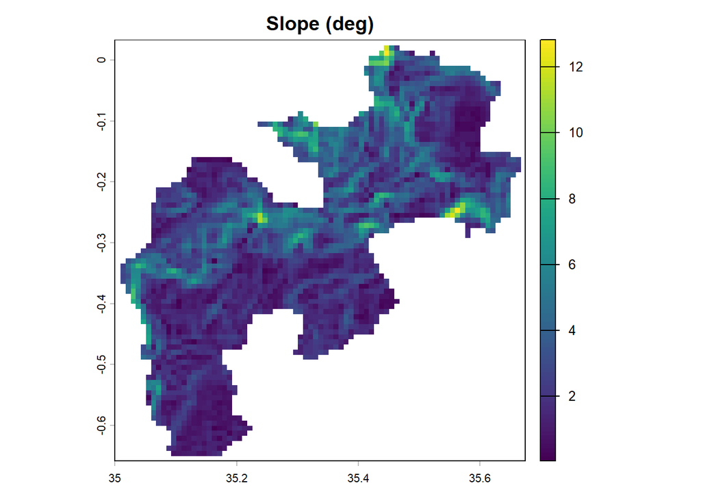

```r
slope_k <- terrain(elev_k, v = "slope", unit = "degrees")
plot(slope_k, main = "Slope (deg)")
```

### Climate (WorldClim 2.1 monthly normals)

```r
prec <- worldclim_country("KEN", var = "prec", path = "data")
tavg <- worldclim_country("KEN", var = "tavg", path = "data")
```

```r
prec <- rast("data/climate/wc2.1_country/KEN_wc2.1_30s_prec.tif")
tavg <- rast("data/climate/wc2.1_country/KEN_wc2.1_30s_tavg.tif")
nlyr(prec)
```

```
[1] 12
```

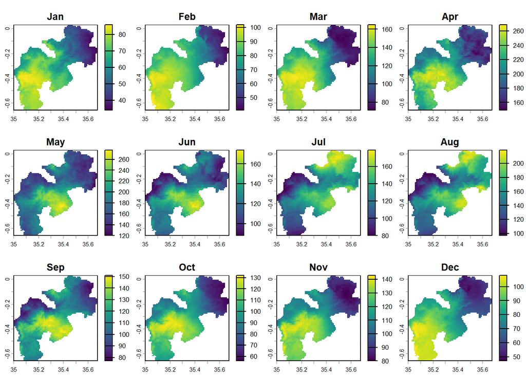

```r
prec_k <- mask(crop(prec, kericho), kericho)
tavg_k <- mask(crop(tavg, kericho), kericho)
names(prec_k) <- names(tavg_k) <- month.abb
plot(prec_k)
```

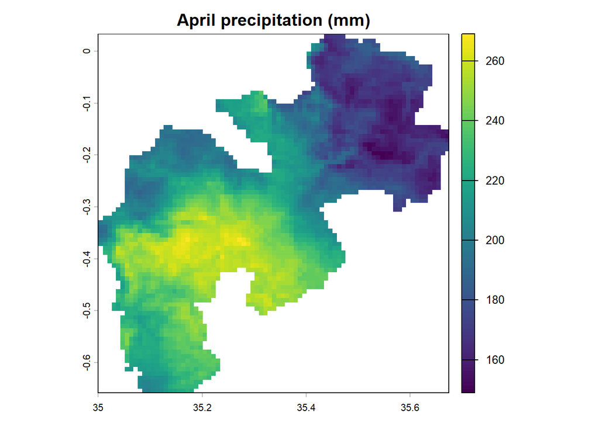

```r
plot(prec_k[["Apr"]], main = "April precipitation (mm)")
```

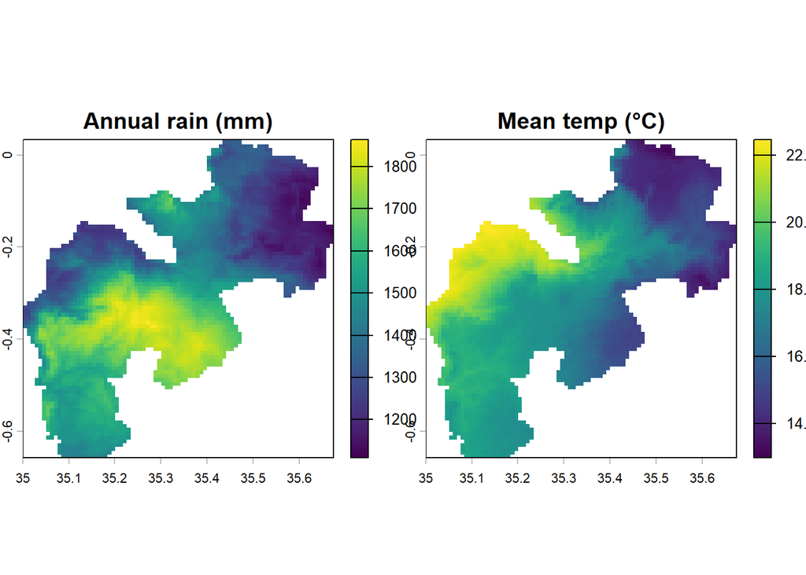

```r
prec_annual <- sum(prec_k)
tavg_annual <- mean(tavg_k)
plot(c(prec_annual, tavg_annual), main = c("Annual rain (mm)", "Mean temp (°C)"))
```

```r
compareGeom(elev_k, prec_annual, stopOnError = FALSE)
```

```
[1] TRUE
```

```r
prec_annual <- resample(prec_annual, elev_k, method = "bilinear")
tavg_annual <- resample(tavg_annual, elev_k, method = "bilinear")
```

## 2.3 Raster algebra, reclassification, tea suitability

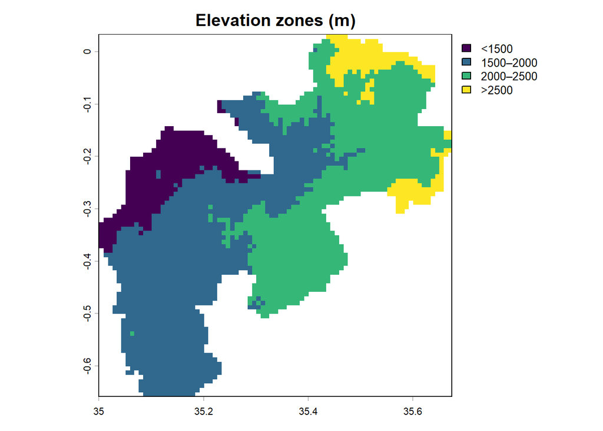

```r
rcl <- matrix(c(-Inf, 1500, 1,
                1500, 2000, 2,
                2000, 2500, 3,
                2500,  Inf, 4), ncol = 3, byrow = TRUE)
elev_zone <- classify(elev_k, rcl)
levels(elev_zone) <- data.frame(id = 1:4,
                                zone = c("<1500", "1500–2000", "2000–2500", ">2500"))
plot(elev_zone, main = "Elevation zones (m)")
```

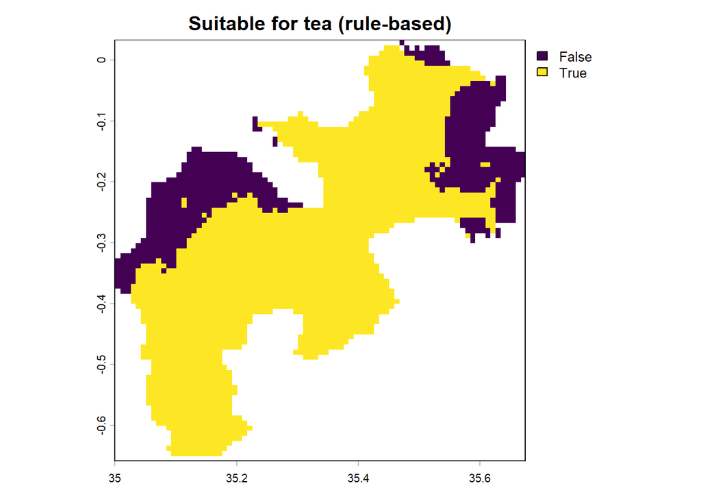

```r
tea_suit <- elev_k >= 1500 & elev_k <= 2700 &
            prec_annual >= 1200 &
            tavg_annual >= 13 & tavg_annual <= 25 &
            slope_k < 30
plot(tea_suit, main = "Suitable for tea (rule-based)")
```

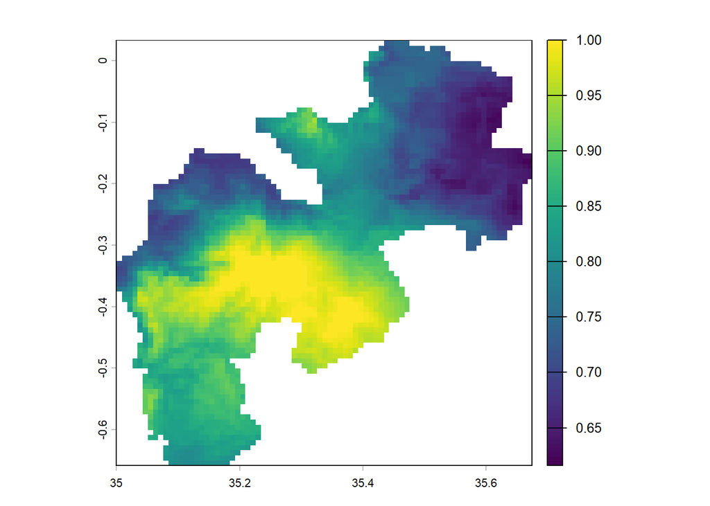

```r
rain_score <- ifel(prec_annual > 1800, 1, prec_annual / 1800)
plot(rain_score)
```

```r
global(cellSize(tea_suit, unit = "km") * tea_suit, "sum", na.rm = TRUE)
```

```
          sum
area 1942.063
```

```r
expanse(kericho, unit = "km")
```

```
[1] 2576.28
```

## 2.4 From rasters to variables

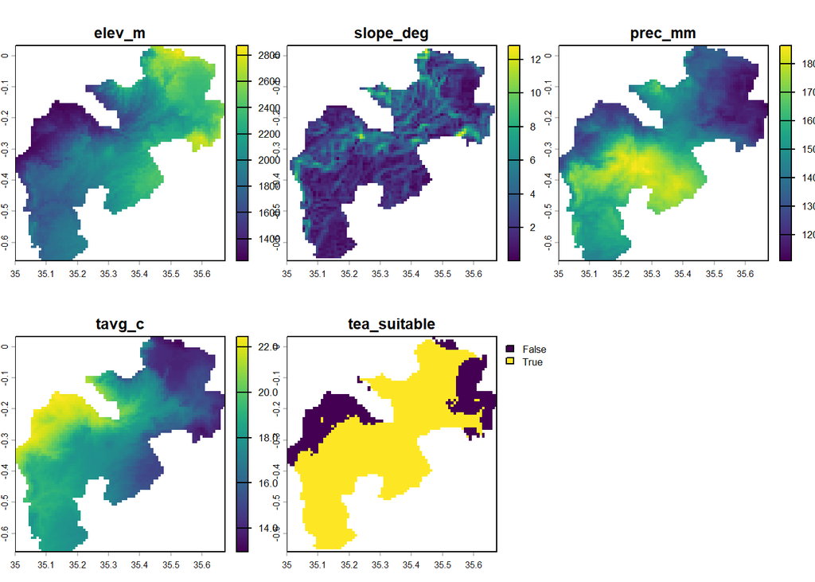

```r
covs <- c(elev_k, slope_k, prec_annual, tavg_annual, tea_suit)
names(covs) <- c("elev_m", "slope_deg", "prec_mm", "tavg_c", "tea_suitable")
plot(covs)
```

### Farm level: points and buffers

`tidyverse` masks `terra::extract` with `tidyr::extract`, so always write `terra::extract`.

```r
farm_env <- terra::extract(covs, farms, ID = FALSE)
farms_df <- cbind(as.data.frame(farms), farm_env)
head(farms_df)
```

```
  farm_id      lon        lat  crop hh_size income_kes      subcounty
1       1 35.34752 -0.2743741 maize       2      82634        Ainamoi
2       5 35.12948 -0.3719336   tea       6     155788   Sigowet/Soin
3       6 35.49265 -0.2455014 maize       6     101546 Kipkelion East
4       7 35.41913 -0.3717153   tea       1     221882         Belgut
5       8 35.35305 -0.4501647   tea       5      70645         Belgut
6       9 35.55155 -0.2557584 dairy       5     107107 Kipkelion East
            ward dist_town_km elev_m slope_deg prec_mm   tavg_c tea_suitable
1        Kapsaos     12.42454   1869  2.924691    1537 18.26667         TRUE
2    Kaplelartet     17.46344   1811  3.402889    1746 18.63333         TRUE
3 Kedowa/Kimugul     26.69586   2240  1.317149    1379 15.99167         TRUE
4          Chaik     14.79252   2319  1.152117    1720 15.34167         TRUE
5          Chaik     11.81056   2197  1.266846    1783 16.21667         TRUE
6 Kedowa/Kimugul     32.04879   2490 11.964116    1323 14.60833         TRUE
```

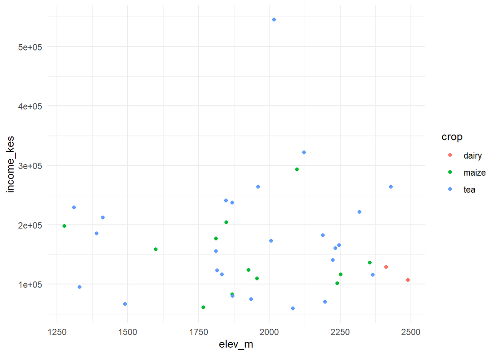

```r
farm_env_1km <- terra::extract(covs[[1:4]], buffer(farms, 1000), fun = mean,
                               na.rm = TRUE, ID = FALSE)
names(farm_env_1km) <- paste0(names(farm_env_1km), "_1km")
farms_df <- cbind(farms_df, farm_env_1km)

ggplot(farms_df, aes(elev_m, income_kes, colour = crop)) +
  geom_point() + theme_minimal()
```

### Ward level: zonal statistics

```r
ward_env <- terra::extract(covs[[1:4]], wards, fun = mean, na.rm = TRUE, ID = FALSE)
ward_df  <- cbind(as.data.frame(wards)[, c("NAME_2", "NAME_3")], ward_env)
head(ward_df)
```

```
   NAME_2      NAME_3   elev_m slope_deg  prec_mm   tavg_c
1 Ainamoi     Ainamoi 1729.625  4.509706 1529.403 19.36505
2 Ainamoi Kapkugerwet 2062.429  1.641791 1795.762 17.54167
3 Ainamoi     Kapsaos 1900.228  3.013576 1559.842 18.19240
4 Ainamoi     Kapsoit 1867.529  4.050891 1691.014 18.54298
5 Ainamoi   Kipchebor 1979.429  1.143729 1817.405 17.69067
6 Ainamoi Kipchimchim 2017.960  2.380964 1790.200 17.73833
```

```r
library(exactextractr)
wards_sf <- st_as_sf(wards)
ward_exact <- exact_extract(covs[[1:4]], wards_sf, "mean", append_cols = "NAME_3",
                            progress = FALSE)
head(ward_exact)
```

```
       NAME_3 mean.elev_m mean.slope_deg mean.prec_mm mean.tavg_c
1     Ainamoi    1721.993       4.578368     1523.386    19.42138
2 Kapkugerwet    2061.971       1.728743     1795.380    17.54329
3     Kapsaos    1899.617       3.084930     1560.941    18.20069
4     Kapsoit    1869.376       3.895622     1693.181    18.52580
5   Kipchebor    1980.198       1.213199     1817.045    17.68426
6 Kipchimchim    2021.711       2.377232     1791.857    17.72633
```

### Panel-style table: ward × month rainfall

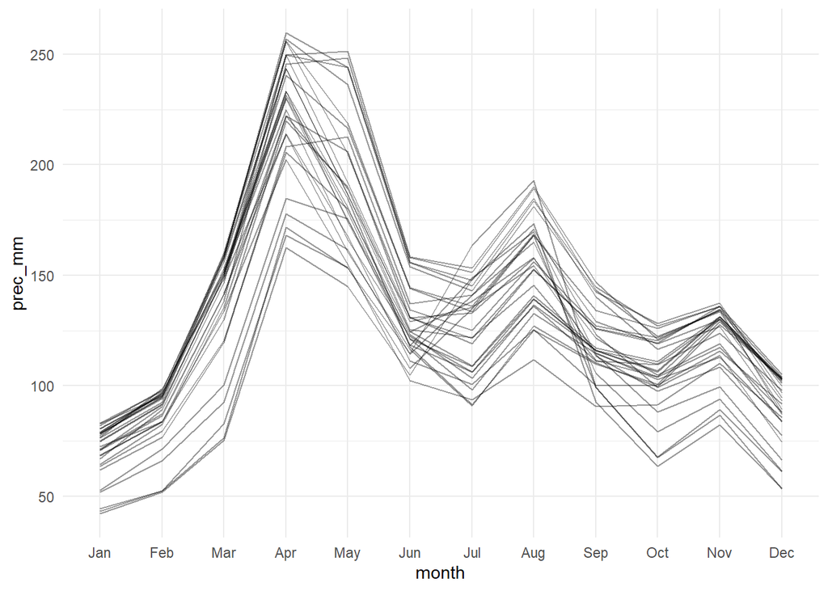

```r
ward_month <- exact_extract(prec_k, wards_sf, "mean", append_cols = "NAME_3",
                            progress = FALSE) |>
  pivot_longer(-NAME_3, names_to = "month", values_to = "prec_mm") |>
  mutate(month = factor(sub("mean.", "", month), levels = month.abb))

ggplot(ward_month, aes(month, prec_mm, group = NAME_3)) +
  geom_line(alpha = 0.4) + theme_minimal()
```

### Save *(not run)*

```r
writeRaster(covs, "output/kericho_covariates.tif", overwrite = TRUE)
write.csv(farms_df, "output/farms_with_covariates.csv", row.names = FALSE)
write.csv(ward_df,  "output/wards_with_covariates.csv", row.names = FALSE)
```

## 2.5 Exercise and bridge to Google Earth Engine

1. Share of each ward’s area that is “suitable for tea” (hint: `exact_extract()` with `"mean"` on `tea_suit`).
2. Wettest month per ward from `ward_month`.

These were ~1 km static layers that fit on a laptop. Satellite images (10–30 m, every few days, years of data) do not, so from next week the same logic (crop, mask, algebra, extract, zonal statistics) moves to Google Earth Engine. **Homework:** register at https://code.earthengine.google.com with a noncommercial (education) Cloud project before 19.11.